# week5

danbom

2020 10 2

## Base R

```r
suppressMessages(library(tidyverse))
```

## R Objects and Variables

- Everything in R is stored as an object, which is associated with a variable name.
- An object is a technical terminology defined in Object Oriented Programming (OOP). (OOP is an important concept but not in this class)
- A variable name can be assigned to an object using the assignment operator.

```r
# store a number to a variable named `a`
a <- 0.2
```

```r
# print a
a
```

```
## [1] 0.2
```

```r
# store a vector to a variable named `b`
b <- c(1,4,9)
```

```r
# print b
b
```

```
## [1] 1 4 9
```

```r
z <- 5
i <- (z * 2 + 45)/2
i
```

```
## [1] 27.5
```

# Function

```r
# call (execute or run) the mean() function
mean(c(1,2,3,4))
```

```
## [1] 2.5
```

```r
# mean() will not work with NA
mean(c(1,2,NA,4))
```

```
## [1] NA
```

```r
# When na.rm = TRUE, NA will be removed before computation
mean(c(1,2,NA,4), na.rm = TRUE)
```

```
## [1] 2.333333
```

## User-Defined Functions

- function.name <- function(arg1, arg2, arg3){body}

```r
# Define se() function that calculate the standard error
se <- function(x) {
  v <- var(x)
  n <- length(x)
  return(sqrt(v/n))
}
```

```r
mySample <- rnorm(n=100, mean=20, sd=4)
mySample # sd는 표준편차
```

```
##   [1] 24.01115 22.97396 18.83189 14.29803 21.36417 17.25065 18.79859 20.67700
##   [9] 14.60486 24.59835 22.89558 20.34859 22.23480 16.13336 17.61715 16.04227
##  [17] 25.26158 18.18989 18.16644 17.20975 21.73547 22.36283 11.67680 27.23059
##  [25] 14.61828 27.04563 25.22038 17.35275 18.16668 16.73789 17.72333 24.12222
##  [33] 16.30192 20.55298 23.27231 16.57217 22.70510 22.38697 20.07791 19.99645
##  [41] 19.57180 21.56213 20.40123 21.31913 12.82807 21.75400 18.46510 21.79957
##  [49] 21.14180 18.89168 17.76166 28.33712 16.92870 21.64747 22.66067 15.11230
##  [57] 21.02540 22.56071 25.62217 17.40289 22.12919 15.78567 17.24030 26.40868
##  [65] 20.43820 18.52527 28.90648 14.60397 25.45501 14.99908 25.71075 21.84881
##  [73] 17.48396 17.70633 20.58773 11.45866 21.79737 19.25858 24.17770 15.70237
##  [81] 23.24727 24.15905 17.17168 14.74168 23.44457 19.77683 18.31428 20.38054
##  [89] 21.32380 18.41360 18.42980 28.41355 20.58580 27.19193 17.60400 15.81937
##  [97] 18.23296 26.97103 22.01883 14.76308
```

```r
se(mySample)
```

```
## [1] 0.3867679
```

```r
x1 <- rnorm(100, mean=0, sd=1)  # generate 100 random numbers from Normal(0,1)
x2 <- rnorm(100, mean=3, sd=2)  # generate 100 random numbers from Normal(3,2)
```

## Vectors

- Type : typeof() returns the type of an object.
- Attributes: attributes() returns additional arbitrary metadata

```r
typeof(c(1,2,3))
```

```
## [1] "double"
```

```r
length(c(1,2,3))
```

```
## [1] 3
```

```r
attributes(c(1,2,3))
```

[output not shown]

## Attributes

```r
a <- c(x=1,y=2,z=3)   # when creating
names(a)
```

```
## [1] "x" "y" "z"
```

```r
names(a) <- c("l", "m", "n")   # by modifying existing names
a
```

```
## l m n
## 1 2 3
```

```r
attributes(a)    # names are attributes
```

```
## $names
## [1] "l" "m" "n"
```

```r
attributes(mtcars)
```

```
## $names
##  [1] "mpg"  "cyl"  "disp" "hp"   "drat" "wt"   "qsec" "vs"   "am"   "gear"
## [11] "carb"
##
## $row.names
##  [1] "Mazda RX4"           "Mazda RX4 Wag"       "Datsun 710"
##  [4] "Hornet 4 Drive"      "Hornet Sportabout"   "Valiant"
##  [7] "Duster 360"          "Merc 240D"           "Merc 230"
## [10] "Merc 280"            "Merc 280C"           "Merc 450SE"
## [13] "Merc 450SL"          "Merc 450SLC"         "Cadillac Fleetwood"
## [16] "Lincoln Continental" "Chrysler Imperial"   "Fiat 128"
## [19] "Honda Civic"         "Toyota Corolla"      "Toyota Corona"
## [22] "Dodge Challenger"    "AMC Javelin"         "Camaro Z28"
## [25] "Pontiac Firebird"    "Fiat X1-9"           "Porsche 914-2"
## [28] "Lotus Europa"        "Ford Pantera L"      "Ferrari Dino"
## [31] "Maserati Bora"       "Volvo 142E"
##
## $class
## [1] "data.frame"
```

## Type Coercion (Conversion)

```r
v <- c(4, 7, 23.5, 76.2, 80, "rrt", 90)
v
```

```
## [1] "4"    "7"    "23.5" "76.2" "80"   "rrt"  "90"
```

```r
typeof(v)
```

```
## [1] "character"
```

```r
sum(c(TRUE, FALSE, TRUE))
```

```
## [1] 2
```

- You can explicitly convert data type with as.character(), as.double(), as.integer(), and as.logical().

```r
a <- c(1,2,3)
a
```

```
## [1] 1 2 3
```

```r
b <- as.character(a)
b
```

```
## [1] "1" "2" "3"
```

## NA represents missing

```r
u <- c(4, 6, NA, 2)
u
```

```
## [1]  4  6 NA  2
```

```r
k <- c(TRUE, FALSE, FALSE, NA, TRUE)
k
```

```
## [1]  TRUE FALSE FALSE    NA  TRUE
```

## Generate a vector

```r
# c() also combine vectors
a <- c(1,2,3)
b <- c(4,5,6)
c <- c(a, b)
c
```

```
## [1] 1 2 3 4 5 6
```

```r
# k:n generates a vector whose elements are the sequence of numbers from k to n
1:10
```

```
##  [1]  1  2  3  4  5  6  7  8  9 10
```

```r
# seq() generates regular sequence
# seq(from, to)
seq(1, 10)
```

```
##  [1]  1  2  3  4  5  6  7  8  9 10
```

```r
# seq(from, to, by)
seq(1, 10, 2)
```

```
## [1] 1 3 5 7 9
```

```r
# rep(x, times) replicates the values in x multiple times
# x can be a number or vector
# replicates 1 5 times
rep(1, 5)
```

```
## [1] 1 1 1 1 1
```

```r
# replicates c(1, 2) 5 times
rep(c(1,2), 5)
```

```
##  [1] 1 2 1 2 1 2 1 2 1 2
```

```r
# each element of c(1,2) is repeated 5 times
rep(c(1,2), each = 5)
```

```
##  [1] 1 1 1 1 1 2 2 2 2 2
```

```r
# rnorm(n, mean = 0, sd = 1) generates a vector of n random samples
# from a normal distribution with specific mean and sd.
rnorm(100)
```

```
##   [1]  0.544522753  0.292320198  0.290210446  1.667827723  0.503423824
##   [6] -1.132927247 -1.344117711 -0.725700298 -0.391889464 -1.029617962
##  [11] -0.264955907  0.550179410  0.431141901  0.406221966 -0.033237139
##  [16] -0.210377686 -0.352214720  1.102249371  1.026228084 -2.354085717
##  [21] -1.036052820 -0.151148959  0.061224421  0.953713192  2.255143942
##  [26]  0.442911613  0.005107541 -0.017007506  1.327791760 -1.558049215
##  [31] -0.468888434 -0.871817340  1.761748958  2.136496865  0.298301657
##  [36] -0.042097692  0.322080095  0.011529533 -1.516342594 -1.187279315
##  [41]  0.381036591 -0.833542111 -0.987822434 -1.480320297 -2.413678354
##  [46] -0.460901437  0.645526036  1.835809364  0.291139589  1.825179578
##  [51] -0.720052006  0.136736138 -0.642789032 -0.711792309 -0.318431615
##  [56]  0.588714128  2.256790167 -1.021108284  1.087516823  1.205787606
##  [61] -0.213321018 -1.770265617  0.976671242  0.804889101 -0.613382272
##  [66]  1.465711240 -0.989489349  0.429985552  0.250749217  0.520864804
##  [71]  0.853330278  0.358699555  1.079623173 -1.839735279  0.034507259
##  [76] -0.381422663 -1.894400317 -1.061210623 -0.098647626  0.472098651
##  [81] -0.883600979 -2.001125080 -0.055404978 -0.518030698  0.140557517
##  [86]  0.757751492 -0.590901175 -1.651415907 -0.442819026  0.087224151
##  [91] -0.090722535  0.020189377 -0.605701556 -0.884375935 -2.115630804
##  [96] -0.846471436  1.026424531  0.495879611 -0.315276098 -0.135676968
```

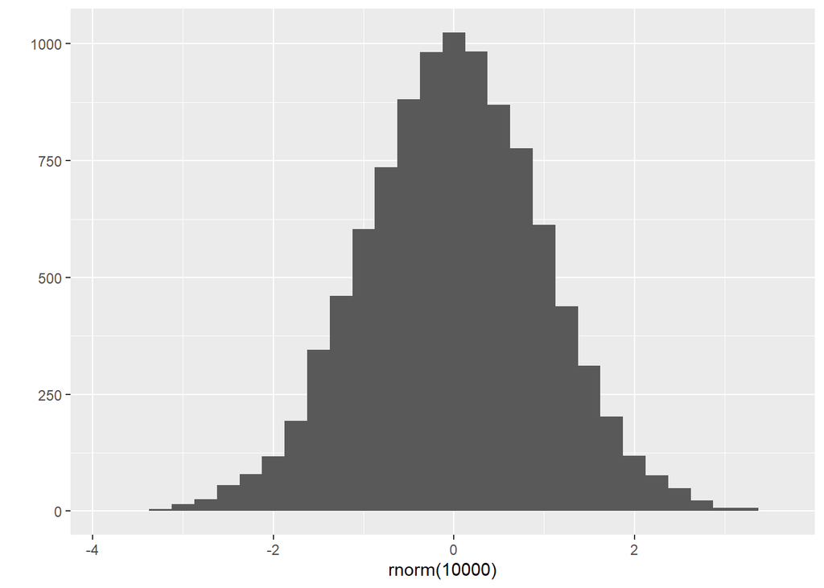

```r
qplot(rnorm(10000))
```

```r
# runif(n, min, max) generates a vector of n random samples
# from a uniform distribution whose limits are min and max.
runif(100, 0, 1)
```

```
##   [1] 0.4613410393 0.1180280717 0.2913006099 0.3520393071 0.2176318076
##   [6] 0.1835046215 0.6766596134 0.1755466447 0.9557250361 0.1724794905
##  [11] 0.4075342028 0.9896147216 0.4358931670 0.9823330385 0.4832569240
##  [16] 0.9707549051 0.5954703805 0.6453079467 0.5438533551 0.9697078476
##  [21] 0.1758776570 0.6588320259 0.0630178014 0.7441420408 0.1462472244
##  [26] 0.5223965733 0.8515587249 0.3151860679 0.8938706613 0.6403453101
##  [31] 0.4959546593 0.0452033065 0.7679415243 0.3330453485 0.3200984383
##  [36] 0.9825609087 0.4160221959 0.3596685003 0.2728242623 0.6941662026
##  [41] 0.2808657794 0.8413302775 0.6551854238 0.9367087733 0.7541022247
##  [46] 0.2670228651 0.1328862722 0.9642489823 0.0191715071 0.9826726965
##  [51] 0.0001422053 0.6657045486 0.1611936975 0.6961979859 0.2070830113
##  [56] 0.2552644992 0.3805417276 0.6552228532 0.3413706901 0.5559002892
##  [61] 0.9547234641 0.6708211387 0.7431999904 0.2076985920 0.3822944653
##  [66] 0.5709417302 0.5520922914 0.5441488486 0.4842211679 0.6192713657
##  [71] 0.9176398772 0.2774748805 0.9899562616 0.2808257251 0.0086188323
##  [76] 0.9200465840 0.6883033353 0.8446355874 0.4105489589 0.5964450990
##  [81] 0.7955680992 0.5616288711 0.6508412450 0.2908988325 0.2213991268
##  [86] 0.8577828708 0.1578830774 0.9619099554 0.6391878475 0.9791561936
##  [91] 0.2626862929 0.6614548652 0.3713799617 0.3156081315 0.0483576290
##  [96] 0.2957178641 0.8006994412 0.5755161026 0.8776502165 0.3591478881
```

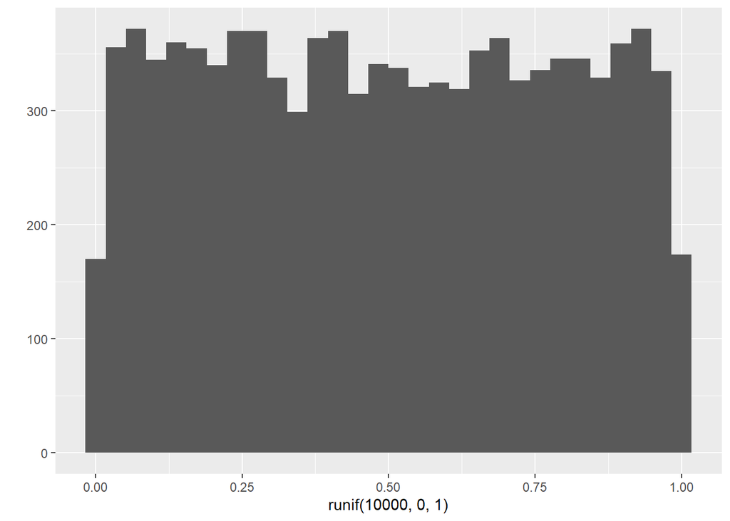

```r
qplot(runif(10000, 0, 1))
```

## Indexing or subsetting a Vector

- Positive integers return elements at the specified positions.

```r
x <- c(2,3,4,5,6,7)
x[c(3,1)]
```

```
## [1] 4 2
```

- Negative integers omit elements at the specified positions:

```r
x[-c(3,1)]
```

```
## [1] 3 5 6 7
```

```r
x[c(TRUE, TRUE, FALSE, FALSE, TRUE, TRUE)]
```

```
## [1] 2 3 6 7
```

```r
x > 3
```

```
## [1] FALSE FALSE  TRUE  TRUE  TRUE  TRUE
```

```r
# This is called a logical indexing, which is a very powerful tool.
# > : greater than (Logical Operators)
x[x > 3]
```

```
## [1] 4 5 6 7
```

```r
x[x > 3 & x < 5]
```

```
## [1] 4
```

```r
# %in% operator
# v1 %in% v2 returns a logical vector indicating
# whether the elements of v1 are included in v2.
c(1,2,3) %in% c(2,3,4,5,6)
```

```
## [1] FALSE  TRUE  TRUE
```

```r
a <- c(1,2,3,4,5)
a
```

```
## [1] 1 2 3 4 5
```

```r
a[c(1,5)] <- 100
a
```

```
## [1] 100   2   3   4 100
```

```r
a <- c(1,2,3,NA,5,6,NA)
a
```

```
## [1]  1  2  3 NA  5  6 NA
```

```r
# is.na indicates which elements are missing
is.na(a)  # returns TRUE when missing
```

```
## [1] FALSE FALSE FALSE  TRUE FALSE FALSE  TRUE
```

```r
# Type conversion: TRUE and FALSE will be converted into 1 and 0, respectively.
# This expression answers the question: How many NSs are in a?
sum(is.na(a))
```

```
## [1] 2
```

```r
# !x = not x (negation)
!is.na(a)  # returns TRUE when not missing
```

```
## [1]  TRUE  TRUE  TRUE FALSE  TRUE  TRUE FALSE
```

```r
# This expression answers the question: How many non-NSs are in a?
sum(!is.na(a))
```

```
## [1] 5
```

```r
# logical indexing
a[is.na(a)] <- 999
a
```

```
## [1]   1   2   3 999   5   6 999
```

```r
# create a vector with names
a <- c(x = 1, y = 2, z = 3)
a
```

```
## x y z
## 1 2 3
```

```r
# named vector can be indexed using their names
a[c("x", "z")]
```

```
## x z
## 1 3
```

```r
# R uses a "recycling rule" by repeating the shorter vector
# In this example, R recycled c(TRUE, FALSE) to produce c(TRUE, FALSE, TRUE, FALSE)
i <- c(TRUE, FALSE)
a <- c(1,2,3,4)
a[i]
```

```
## [1] 1 3
```

```r
# R uses a "recycling rule" by repeating the shorter vector
v1 <- c(4,5,6,7)
v2 <- c(10,10)
v1+v2
```

```
## [1] 14 15 16 17
```

## Arrange a vector

```r
# sort(x, decreasing = FALSE)
# By default, sort() sorts ascending order.
sort(c(5,6,4))
```

```
## [1] 4 5 6
```

```r
# sorts into descending order
sort(c(5,6,4), decreasing = TRUE)
```

```
## [1] 6 5 4
```

```r
# rev() provides a reversed version of its argument
rev(c(5,6,4))
```

```
## [1] 4 6 5
```

```r
# rank() returns the sample ranks of the elements in a vector
rank(c(5,6,4))
```

```
## [1] 2 3 1
```

```r
# order() returns a permutation which rearranges
# its first argument into ascending or descending order.
# What this means is order(c(5,6,4))
# 1) first sorts a vector in ascending order to produce c(4,5,6)
# 2) and returns the indices of the sorted element in the original vector.
# e.g., we have 3 first b/c the index of 4 in the original vector is 3
# e.g., we have 1 first b/c the index of 5 in the original vector is 1
# e.g., we have 2 first b/c the index of 6 in the original vector is 2
order(c(5,6,4))
```

```
## [1] 3 1 2
```

```r
# We use order() to sort a vector or dataframe
a <- c(5,6,4)
a[order(a)]
```

```
## [1] 4 5 6
```

```r
# sort a dataframe
head(mtcars[order(mtcars$mpg), ])
```

```
##                      mpg cyl disp  hp drat    wt  qsec vs am gear carb
## Cadillac Fleetwood  10.4   8  472 205 2.93 5.250 17.98  0  0    3    4
## Lincoln Continental 10.4   8  460 215 3.00 5.424 17.82  0  0    3    4
## Camaro Z28          13.3   8  350 245 3.73 3.840 15.41  0  0    3    4
## Duster 360          14.3   8  360 245 3.21 3.570 15.84  0  0    3    4
## Chrysler Imperial   14.7   8  440 230 3.23 5.345 17.42  0  0    3    4
## Maserati Bora       15.0   8  301 335 3.54 3.570 14.60  0  1    5    8
```

## Vectorization of Functions

```r
v <- c(1,4,25)
sqrt(v)
```

```
## [1] 1 2 5
```

```r
v <- c(1,2,3)
v^2
```

```
## [1] 1 4 9
```

```r
# mean will be subtracted from every element of v1
v1 <- c(1,2,3,4)
v1 - mean(v1)
```

```
## [1] -1.5 -0.5  0.5  1.5
```

## More functions

```r
# table() creates a frequency table
a <- c(1, 1, 2, 2, 2, 3, 3, 3, 4, 4, 4, 4, 4)
table(a)
```

```
## a
## 1 2 3 4
## 2 3 3 5
```

```r
# unique() returns a vector of unique elements
unique(a)
```

```
## [1] 1 2 3 4
```

```r
a <- c(1,2,3,NA,5)
```

```r
# na.rm = TRUE removes NAs before computation
mean(a, na.rm = TRUE)
```

```
## [1] 2.75
```

## Generating Sequences

```r
5:0
```

```
## [1] 5 4 3 2 1 0
```

```r
seq(from=1, to=3, by=0.5)
```

```
## [1] 1.0 1.5 2.0 2.5 3.0
```

```r
rep(1:2, 3)
```

```
## [1] 1 2 1 2 1 2
```

```r
# gl() generates sequences involving factors
# gl(k,n), k = the number of levels,
# n = the number of repetitions.
gl(7,3)
```

```
##  [1] 1 1 1 2 2 2 3 3 3 4 4 4 5 5 5 6 6 6 7 7 7
## Levels: 1 2 3 4 5 6 7
```

## Exercise

```r
a <- mtcars$mpg
```

```r
length(a)
```

```
## [1] 32
```

```r
# 평균구하기
sum(a)/length(a)
```

```
## [1] 20.09062
```

```r
mean(a)
```

```
## [1] 20.09062
```

- Calculate the variance of a using sd() function.

```r
sd(a)^2
```

```
## [1] 36.3241
```

```r
var(a)
```

```
## [1] 36.3241
```

```r
sum((a-mean(a))^2)/(length(a)-1)
```

```
## [1] 36.3241
```

- Standardize the vector a

```r
(a-mean(a))/sd(a)
```

```
##  [1]  0.15088482  0.15088482  0.44954345  0.21725341 -0.23073453 -0.33028740
##  [7] -0.96078893  0.71501778  0.44954345 -0.14777380 -0.38006384 -0.61235388
## [13] -0.46302456 -0.81145962 -1.60788262 -1.60788262 -0.89442035  2.04238943
## [19]  1.71054652  2.29127162  0.23384555 -0.76168319 -0.81145962 -1.12671039
## [25] -0.14777380  1.19619000  0.98049211  1.71054652 -0.71190675 -0.06481307
## [31] -0.84464392  0.21725341
```

```r
scale(a)
```

```
##              [,1]
##  [1,]  0.15088482
##  [2,]  0.15088482
##  [3,]  0.44954345
##  [4,]  0.21725341
##  [5,] -0.23073453
##  [6,] -0.33028740
##  [7,] -0.96078893
##  [8,]  0.71501778
##  [9,]  0.44954345
## [10,] -0.14777380
## [11,] -0.38006384
## [12,] -0.61235388
## [13,] -0.46302456
## [14,] -0.81145962
```

[output cut: 22 more lines]

```r
max(a)-min(a)
```

```
## [1] 23.5
```

```r
# another solution
diff(range(a))
```

```
## [1] 23.5
```

- Normalize the vector a

```r
# your maximum value will be 1, and minimum value will be 0.
(a-min(a))/(max(a)-min(a))
```

```
##  [1] 0.4510638 0.4510638 0.5276596 0.4680851 0.3531915 0.3276596 0.1659574
##  [8] 0.5957447 0.5276596 0.3744681 0.3148936 0.2553191 0.2936170 0.2042553
## [15] 0.0000000 0.0000000 0.1829787 0.9361702 0.8510638 1.0000000 0.4723404
## [22] 0.2170213 0.2042553 0.1234043 0.3744681 0.7191489 0.6638298 0.8510638
## [29] 0.2297872 0.3957447 0.1957447 0.4680851
```

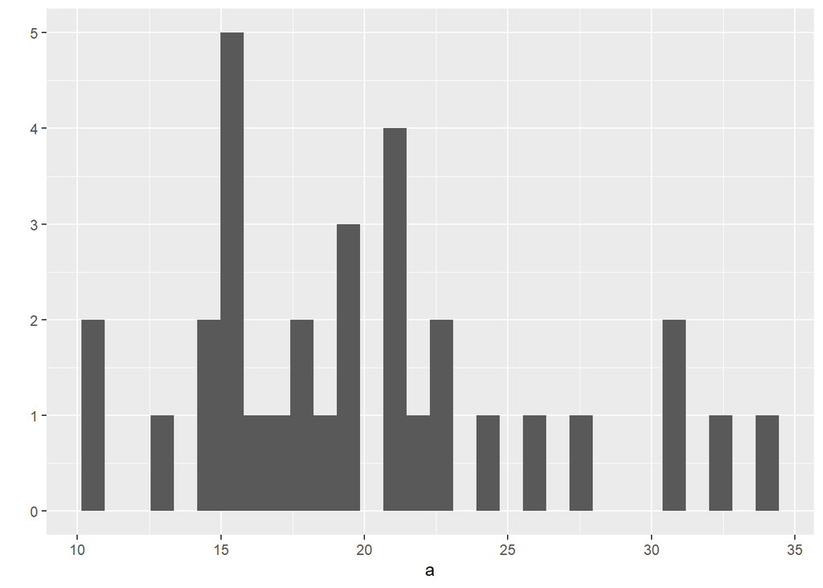

```r
qplot(a)
```

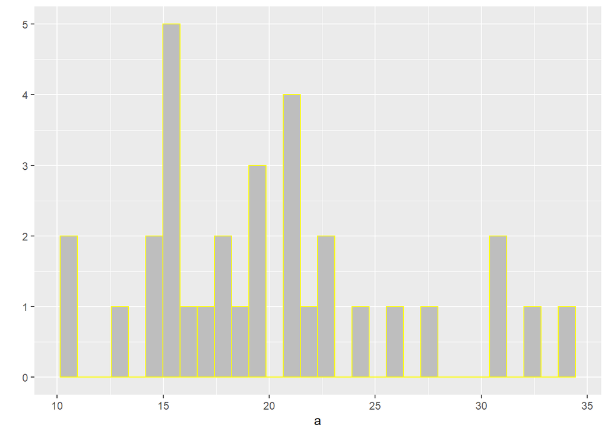

```r
# To set aesthetics, wrap in I()
qplot(a, color = I("yellow"), fill = I("gray"))
```

```r
# creates a logical vector in which TRUE indicates the element that is larger than 20
a>20
```

```
##  [1]  TRUE  TRUE  TRUE  TRUE FALSE FALSE FALSE  TRUE  TRUE FALSE FALSE FALSE
## [13] FALSE FALSE FALSE FALSE FALSE  TRUE  TRUE  TRUE  TRUE FALSE FALSE FALSE
## [25] FALSE  TRUE  TRUE  TRUE FALSE FALSE FALSE  TRUE
```

```r
# This is a logical indexing where the logical vector
# within the subsetting operator (i.e., []) will create a vector with elements larger than 20.
a[a>20]
```

```
##  [1] 21.0 21.0 22.8 21.4 24.4 22.8 32.4 30.4 33.9 21.5 27.3 26.0 30.4 21.4
```

```r
length(a[a>20])
```

```
## [1] 14
```

```r
# same result
# this happens because of "vectorization" and "type conversion"
sum(a>20)
```

```
## [1] 14
```

## Factors

- Factors are used to represent categorical data (e.g., gender, states).

## creating

```r
# levels are the set of allowed values
f1 <- factor(c(2,1,1,3,2,1,1))
f1
```

```
## [1] 2 1 1 3 2 1 1
## Levels: 1 2 3
```

```r
typeof(f1)
```

```
## [1] "integer"
```

```r
attributes(f1)
```

```
## $levels
## [1] "1" "2" "3"
##
## $class
## [1] "factor"
```

```r
levels(f1)
```

```
## [1] "1" "2" "3"
```

- The factor’s level is a character vector.

```r
# test for objects of type "character"
is.character(levels(f1))
```

```
## [1] TRUE
```

- can change levels

```r
levels(f1) <- c("one", "two", "three")
f1
```

```
## [1] two   one   one   three two   one   one
## Levels: one two three
```

```r
f2 <- factor(c("Dec", "Apr", "Jan", "Mar"))
f2
```

```
## [1] Dec Apr Jan Mar
## Levels: Apr Dec Jan Mar
```

```r
sort(f2)
```

```
## [1] Apr Dec Jan Mar
## Levels: Apr Dec Jan Mar
```

```r
month_levels <- c(
  "Jan", "Feb", "Mar", "Apr", "May", "Jun",
  "Jul", "Aug", "Sep", "Oct", "Nov", "Dec"
)
f3 <- factor(c("Dec", "Apr", "Jan", "Mar"), levels = month_levels)
f3
```

```
## [1] Dec Apr Jan Mar
## Levels: Jan Feb Mar Apr May Jun Jul Aug Sep Oct Nov Dec
```

```r
# In many cases, this is the result that we expect.
sort(f3)
```

```
## [1] Jan Mar Apr Dec
## Levels: Jan Feb Mar Apr May Jun Jul Aug Sep Oct Nov Dec
```

```r
table(f3)
```

```
## f3
## Jan Feb Mar Apr May Jun Jul Aug Sep Oct Nov Dec
##   1   0   1   1   0   0   0   0   0   0   0   1
```

```r
table(f2)
```

```
## f2
## Apr Dec Jan Mar
##   1   1   1   1
```

```r
# the default level is in alphabetical order
f4 <- factor(c("high", "low", "medium", "medium", "high"))
f4
```

```
## [1] high   low    medium medium high
## Levels: high low medium
```

```r
sort(f4)
```

```
## [1] high   high   low    medium medium
## Levels: high low medium
```

```r
f5 <- factor(c("high", "low", "medium", "medium", "high"), levels = c("low", "medium", "high"))
f5
```

```
## [1] high   low    medium medium high
## Levels: low medium high
```

```r
sort(f5)
```

```
## [1] low    medium medium high   high
## Levels: low medium high
```

```r
f6 <- factor(c("high", "low", "medium", "medium", "high"), levels = c("low", "medium", "high"), ordered = TRUE)
f6
```

```
## [1] high   low    medium medium high
## Levels: low < medium < high
```

```r
min(f6)
```

```
## [1] low
## Levels: low < medium < high
```

```r
f6[1] > f6[2]
```

```
## [1] TRUE
```

```r
f7 <- ordered(c("high", "low", "medium", "medium", "high"), levels = c("low", "medium", "high"))
f7
```

```
## [1] high   low    medium medium high
## Levels: low < medium < high
```

## Exercise

```r
x <- c("Agree", "Disagree", "Neutral", "Agree" ,"Agree", "Strongly disagree", "Neutral")
```

```r
# you may want to this
factor(x, levels = c("Strongly disagree", "Disagree", "Neutral",  "Agree", "Strongly agree"))
```

```
## [1] Agree             Disagree          Neutral           Agree
## [5] Agree             Strongly disagree Neutral
## Levels: Strongly disagree Disagree Neutral Agree Strongly agree
```

```r
x = c("male", "male", "female", "male", "female")
```

```r
# What I've asked you is to change the default alphabetical order using levels options.
factor(x, levels = c("male", "female"))
```

```
## [1] male   male   female male   female
## Levels: male female
```

```r
# I just wanted to introduce 'cut()` function
set.seed(7)
x <- rnorm(100)
cut(x, breaks = quantile(x))
```

```
##   [1] (0.72,2.72]    (-1.79,-0.559] (-1.79,-0.559] (-0.559,0.106] (-1.79,-0.559]
##   [6] (-1.79,-0.559] (0.72,2.72]    (-0.559,0.106] (0.106,0.72]   (0.72,2.72]
##  [11] (0.106,0.72]   (0.72,2.72]    (0.72,2.72]    (0.106,0.72]   (0.72,2.72]
##  [16] (0.106,0.72]   (-1.79,-0.559] (-0.559,0.106] (-0.559,0.106] (0.72,2.72]
##  [21] (0.72,2.72]    (0.106,0.72]   (0.72,2.72]    (-1.79,-0.559] (0.72,2.72]
##  [26] (0.106,0.72]   (0.72,2.72]    (0.106,0.72]   (-1.79,-0.559] (-0.559,0.106]
##  [31] (-1.79,-0.559] (0.106,0.72]   (0.106,0.72]   (-0.559,0.106] (-0.559,0.106]
##  [36] (-1.79,-0.559] (0.72,2.72]    (-1.79,-0.559] (-0.559,0.106] (0.106,0.72]
##  [41] (0.72,2.72]    (-1.79,-0.559] (-0.559,0.106] (-1.79,-0.559] (-0.559,0.106]
##  [46] (-0.559,0.106] (0.72,2.72]    (0.106,0.72]   (-0.559,0.106] (0.72,2.72]
##  [51] (-0.559,0.106] (-0.559,0.106] (0.106,0.72]   (0.72,2.72]    (0.72,2.72]
##  [56] (0.106,0.72]   (-1.79,-0.559] (0.106,0.72]   (0.106,0.72]   (-1.79,-0.559]
##  [61] (-0.559,0.106] (0.106,0.72]   (0.106,0.72]   (0.106,0.72]   (0.106,0.72]
##  [66] (0.72,2.72]    (0.72,2.72]    (0.72,2.72]    (0.72,2.72]    (0.106,0.72]
##  [71] (0.106,0.72]   (-1.79,-0.559] (-1.79,-0.559] (-1.79,-0.559] (-1.79,-0.559]
##  [76] (-1.79,-0.559] (-1.79,-0.559] (-0.559,0.106] (-0.559,0.106] (0.72,2.72]
##  [81] (0.106,0.72]   (-0.559,0.106] (-0.559,0.106] (-0.559,0.106] (-1.79,-0.559]
##  [86] (-0.559,0.106] (-0.559,0.106] (-0.559,0.106] <NA>           (0.106,0.72]
##  [91] (0.72,2.72]    (-1.79,-0.559] (0.106,0.72]   (0.106,0.72]   (0.72,2.72]
##  [96] (-1.79,-0.559] (0.72,2.72]    (-1.79,-0.559] (-0.559,0.106] (-0.559,0.106]
## Levels: (-1.79,-0.559] (-0.559,0.106] (0.106,0.72] (0.72,2.72]
```

## creating

```r
x <- list(1:6, "a", c(TRUE, TRUE, FALSE), c(1.2, 3.3, 4.6, 6.6))
x
```

```
## [[1]]
## [1] 1 2 3 4 5 6
##
## [[2]]
## [1] "a"
##
## [[3]]
## [1]  TRUE  TRUE FALSE
##
## [[4]]
## [1] 1.2 3.3 4.6 6.6
```

```r
# str() display the internal structure of an R object
str(x)
```

```
## List of 4
##  $ : int [1:6] 1 2 3 4 5 6
##  $ : chr "a"
##  $ : logi [1:3] TRUE TRUE FALSE
##  $ : num [1:4] 1.2 3.3 4.6 6.6
```

```r
typeof(x)
```

```
## [1] "list"
```

```r
# In R, lm() is a function that fits a regression model to data.
# In the following R expression, 'mpg' is a dependent variable
# and `disp` and `cyl` are independent variable.
fit <- lm(mpg ~ disp + cyl, data = mtcars)
fit
```

```
##
## Call:
## lm(formula = mpg ~ disp + cyl, data = mtcars)
##
## Coefficients:
## (Intercept)         disp          cyl
##    34.66099     -0.02058     -1.58728
```

```r
typeof(fit)
```

```
## [1] "list"
```

```r
str(fit)
```

```
## List of 12
##  $ coefficients : Named num [1:3] 34.661 -0.0206 -1.5873
##   ..- attr(*, "names")= chr [1:3] "(Intercept)" "disp" "cyl"
##  $ residuals    : Named num [1:32] -0.844 -0.844 -3.289 1.573 4.147 ...
##   ..- attr(*, "names")= chr [1:32] "Mazda RX4" "Mazda RX4 Wag" "Datsun 710" "Hornet 4 Drive" ...
##  $ effects      : Named num [1:32] -113.65 -28.44 -6.81 2.04 4.06 ...
##   ..- attr(*, "names")= chr [1:32] "(Intercept)" "disp" "cyl" "" ...
##  $ rank         : int 3
##  $ fitted.values: Named num [1:32] 21.8 21.8 26.1 19.8 14.6 ...
##   ..- attr(*, "names")= chr [1:32] "Mazda RX4" "Mazda RX4 Wag" "Datsun 710" "Hornet 4 Drive" ...
##  $ assign       : int [1:3] 0 1 2
##  $ qr           :List of 5
##   ..$ qr   : num [1:32, 1:3] -5.657 0.177 0.177 0.177 0.177 ...
##   .. ..- attr(*, "dimnames")=List of 2
##   .. .. ..$ : chr [1:32] "Mazda RX4" "Mazda RX4 Wag" "Datsun 710" "Hornet 4 Drive" ...
##   .. .. ..$ : chr [1:3] "(Intercept)" "disp" "cyl"
##   .. ..- attr(*, "assign")= int [1:3] 0 1 2
##   ..$ qraux: num [1:3] 1.18 1.09 1.19
##   ..$ pivot: int [1:3] 1 2 3
##   ..$ tol  : num 1e-07
##   ..$ rank : int 3
##   ..- attr(*, "class")= chr "qr"
##  $ df.residual  : int 29
##  $ xlevels      : Named list()
##  $ call         : language lm(formula = mpg ~ disp + cyl, data = mtcars)
##  $ terms        :Classes 'terms', 'formula'  language mpg ~ disp + cyl
##   .. ..- attr(*, "variables")= language list(mpg, disp, cyl)
##   .. ..- attr(*, "factors")= int [1:3, 1:2] 0 1 0 0 0 1
##   .. .. ..- attr(*, "dimnames")=List of 2
##   .. .. .. ..$ : chr [1:3] "mpg" "disp" "cyl"
##   .. .. .. ..$ : chr [1:2] "disp" "cyl"
##   .. ..- attr(*, "term.labels")= chr [1:2] "disp" "cyl"
##   .. ..- attr(*, "order")= int [1:2] 1 1
##   .. ..- attr(*, "intercept")= int 1
##   .. ..- attr(*, "response")= int 1
##   .. ..- attr(*, ".Environment")=<environment: R_GlobalEnv>
##   .. ..- attr(*, "predvars")= language list(mpg, disp, cyl)
##   .. ..- attr(*, "dataClasses")= Named chr [1:3] "numeric" "numeric" "numeric"
##   .. .. ..- attr(*, "names")= chr [1:3] "mpg" "disp" "cyl"
##  $ model        :'data.frame':   32 obs. of  3 variables:
##   ..$ mpg : num [1:32] 21 21 22.8 21.4 18.7 18.1 14.3 24.4 22.8 19.2 ...
##   ..$ disp: num [1:32] 160 160 108 258 360 ...
##   ..$ cyl : num [1:32] 6 6 4 6 8 6 8 4 4 6 ...
##   ..- attr(*, "terms")=Classes 'terms', 'formula'  language mpg ~ disp + cyl
##   .. .. ..- attr(*, "variables")= language list(mpg, disp, cyl)
##   .. .. ..- attr(*, "factors")= int [1:3, 1:2] 0 1 0 0 0 1
##   .. .. .. ..- attr(*, "dimnames")=List of 2
##   .. .. .. .. ..$ : chr [1:3] "mpg" "disp" "cyl"
##   .. .. .. .. ..$ : chr [1:2] "disp" "cyl"
##   .. .. ..- attr(*, "term.labels")= chr [1:2] "disp" "cyl"
##   .. .. ..- attr(*, "order")= int [1:2] 1 1
##   .. .. ..- attr(*, "intercept")= int 1
##   .. .. ..- attr(*, "response")= int 1
##   .. .. ..- attr(*, ".Environment")=<environment: R_GlobalEnv>
##   .. .. ..- attr(*, "predvars")= language list(mpg, disp, cyl)
##   .. .. ..- attr(*, "dataClasses")= Named chr [1:3] "numeric" "numeric" "numeric"
##   .. .. .. ..- attr(*, "names")= chr [1:3] "mpg" "disp" "cyl"
##  - attr(*, "class")= chr "lm"
```

## Subsetting a List

```r
my.lst <- list(stud.id=34453,      # creat a list
               stud.name="John",
               stud.marks=c(14.3,12,15,19))
```

```r
my.lst
```

```
## $stud.id
## [1] 34453
##
## $stud.name
## [1] "John"
##
## $stud.marks
## [1] 14.3 12.0 15.0 19.0
```

```r
# [ ] extracts a sub-list
my.lst[1]
```

```
## $stud.id
## [1] 34453
```

```r
typeof(my.lst[1])
```

```
## [1] "list"
```

```r
# [[ ]] extracts the value of an individual element
my.lst[[1]]
```

```
## [1] 34453
```

```r
typeof(my.lst[[1]])
```

```
## [1] "double"
```

```r
# my.lst[[3]] will index the third element of a list, which is a numeric vector
# my.lst[[3]][2] will index the second element of the numeric vector
my.lst[[3]][2]
```

```
## [1] 12
```

```r
# In the case of lists with named elements
# $ extracts the value of an individual element
my.lst$stud.id
```

```
## [1] 34453
```

```r
typeof(my.lst$stud.id)
```

```
## [1] "double"
```

## Exercise

- fit is a list that contains the outputs of the lm() function for linear regression. Explore the structure of the fit object using str().

```r
fit <- lm(mpg ~ disp + cyl, data = mtcars)
fit
```

```
##
## Call:
## lm(formula = mpg ~ disp + cyl, data = mtcars)
##
## Coefficients:
## (Intercept)         disp          cyl
##    34.66099     -0.02058     -1.58728
```

```r
# fit$coefficient is a vector
fit$coefficients
```

```
## (Intercept)        disp         cyl
## 34.66099474 -0.02058363 -1.58727681
```

```r
# So, we can subset the first element using the following expression
fit$coefficients[1]
```

```
## (Intercept)
##    34.66099
```

```r
# We can also use the name of element for indexing.
fit$coefficients["(Intercept)"]
```

```
## (Intercept)
##    34.66099
```

## Data frames

```r
head(iris)
```

```
##   Sepal.Length Sepal.Width Petal.Length Petal.Width Species
## 1          5.1         3.5          1.4         0.2  setosa
## 2          4.9         3.0          1.4         0.2  setosa
## 3          4.7         3.2          1.3         0.2  setosa
## 4          4.6         3.1          1.5         0.2  setosa
## 5          5.0         3.6          1.4         0.2  setosa
## 6          5.4         3.9          1.7         0.4  setosa
```

```r
typeof(iris)
```

```
## [1] "list"
```

```r
str(iris)
```

```
## 'data.frame':    150 obs. of  5 variables:
##  $ Sepal.Length: num  5.1 4.9 4.7 4.6 5 5.4 4.6 5 4.4 4.9 ...
##  $ Sepal.Width : num  3.5 3 3.2 3.1 3.6 3.9 3.4 3.4 2.9 3.1 ...
##  $ Petal.Length: num  1.4 1.4 1.3 1.5 1.4 1.7 1.4 1.5 1.4 1.5 ...
##  $ Petal.Width : num  0.2 0.2 0.2 0.2 0.2 0.4 0.3 0.2 0.2 0.1 ...
##  $ Species     : Factor w/ 3 levels "setosa","versicolor",..: 1 1 1 1 1 1 1 1 1 1 ...
```

## The apply family of functions

- The apply() family of functions refers to apply(), lapply(), sapply(), vapply(), mapply(), rapply(), and tapply().
- Why do we need them? – They will make your code much shorter by replacing your own copy and paste

```r
# A motivating example: check the number of missing values in each column of the following data frame 'm'
m <- data.frame(matrix(c(1,2,3,4,NA,6,7,NA,NA,NA,NA,NA), ncol = 4))
m
```

```
##   X1 X2 X3 X4
## 1  1  4  7 NA
## 2  2 NA NA NA
## 3  3  6 NA NA
```

```r
sum(is.na(m$X1))
```

```
## [1] 0
```

```r
sum(is.na(m$X2))
```

```
## [1] 1
```

```r
sum(is.na(m$X3))
```

```
## [1] 2
```

```r
sum(is.na(m$X4))
```

```
## [1] 3
```

- lapply(X, FUN) – X = a list object in R – FUN = a function in R
- lapply() – takes a function (FUN) – applies it to each element of a list (X) – and returns the results in the form of a list

```r
# This one line of code will still work even when the number of columns are 1000 or more.
lapply(m, function(x) sum(is.na(x)))
```

```
## $X1
## [1] 0
##
## $X2
## [1] 1
##
## $X3
## [1] 2
##
## $X4
## [1] 3
```

```r
# lapply() returns a list, whereas sapply() returns a vector, matrix, or array.
sapply(m, function(x) sum(is.na(x)))
```

```
## X1 X2 X3 X4
##  0  1  2  3
```

## Exercise

```r
# install.packages("psych")
library(psych)
head(bfi)
```

```
##       A1 A2 A3 A4 A5 C1 C2 C3 C4 C5 E1 E2 E3 E4 E5 N1 N2 N3 N4 N5 O1 O2 O3 O4
## 61617  2  4  3  4  4  2  3  3  4  4  3  3  3  4  4  3  4  2  2  3  3  6  3  4
## 61618  2  4  5  2  5  5  4  4  3  4  1  1  6  4  3  3  3  3  5  5  4  2  4  3
## 61620  5  4  5  4  4  4  5  4  2  5  2  4  4  4  5  4  5  4  2  3  4  2  5  5
## 61621  4  4  6  5  5  4  4  3  5  5  5  3  4  4  4  2  5  2  4  1  3  3  4  3
## 61622  2  3  3  4  5  4  4  5  3  2  2  2  5  4  5  2  3  4  4  3  3  3  4  3
## 61623  6  6  5  6  5  6  6  6  1  3  2  1  6  5  6  3  5  2  2  3  4  3  5  6
##       O5 gender education age
## 61617  3      1        NA  16
## 61618  3      2        NA  18
## 61620  2      2        NA  17
## 61621  5      2        NA  17
## 61622  3      1        NA  17
## 61623  1      2         3  21
```

## Matrices and Arrays

```r
a <- 1:6
```

```r
# Get or set specific attributes of an object.
attr(a, "dim") <- c(3,2)
a
```

```
##      [,1] [,2]
## [1,]    1    4
## [2,]    2    5
## [3,]    3    6
```

```r
# by default, a matrix is filled by column
a <- matrix(1:6, ncol=3, nrow=2)
a
```

```
##      [,1] [,2] [,3]
## [1,]    1    3    5
## [2,]    2    4    6
```

```r
a <- matrix(1:6, ncol=3)
a
```

```
##      [,1] [,2] [,3]
## [1,]    1    3    5
## [2,]    2    4    6
```

```r
# a matrix can be filled by row using `byrow = TRUE`
a <- matrix(1:6, ncol=3, nrow=2, byrow = TRUE)
a
```

```
##      [,1] [,2] [,3]
## [1,]    1    2    3
## [2,]    4    5    6
```

```r
# 2행 3열이라는 뜻
attributes(a)
```

```
## $dim
## [1] 2 3
```

```r
dim(a)
```

```
## [1] 2 3
```

```r
b <- array(1:12, c(2,3,2))
b
```

```
## , , 1
##
##      [,1] [,2] [,3]
## [1,]    1    3    5
## [2,]    2    4    6
##
## , , 2
##
##      [,1] [,2] [,3]
## [1,]    7    9   11
## [2,]    8   10   12
```

```r
dim(b)
```

```
## [1] 2 3 2
```

- length() generalises to nrow() and ncol() for matrices, and dim() for arrays.
- names() generalises to rownames() and colnames() for matrices, and dimnames(), a list of character vectors, for arrays.

```r
results <- matrix(c(10, 30, 40, 50, 43, 56, 21, 30), 2, 4, byrow = TRUE)
colnames(results) <- c("1qrt", "2qrt", "3qrt", "4qrt")
rownames(results) <- c("store1", "store2")
results
```

```
##        1qrt 2qrt 3qrt 4qrt
## store1   10   30   40   50
## store2   43   56   21   30
```

## Subsetting a Matrix and Array

```r
a <- matrix(1:9, nrow = 3)
colnames(a) <- c("A", "B", "C")
a
```

```
##      A B C
## [1,] 1 4 7
## [2,] 2 5 8
## [3,] 3 6 9
```

```r
a[c(TRUE, FALSE, TRUE), c("B", "A")]
```

```
##      B A
## [1,] 4 1
## [2,] 6 3
```

```r
a[1, c(2,3)]
```

```
## B C
## 4 7
```

```r
# If you omit any dimension, you obtain full columns or rows
a[2,]
```

```
## A B C
## 2 5 8
```

```r
a[,3]
```

```
## [1] 7 8 9
```

```r
a > 3
```

```
##          A    B    C
## [1,] FALSE TRUE TRUE
## [2,] FALSE TRUE TRUE
## [3,] FALSE TRUE TRUE
```

```r
a[a>3] <- NA
a
```

```
##      A  B  C
## [1,] 1 NA NA
## [2,] 2 NA NA
## [3,] 3 NA NA
```

## Combine Matrices by Columns or Rows

```r
# combine by columns
cbind(a,a)
```

```
##      A  B  C A  B  C
## [1,] 1 NA NA 1 NA NA
## [2,] 2 NA NA 2 NA NA
## [3,] 3 NA NA 3 NA NA
```

```r
# combine by rows
rbind(a,a)
```

```
##      A  B  C
## [1,] 1 NA NA
## [2,] 2 NA NA
## [3,] 3 NA NA
## [4,] 1 NA NA
## [5,] 2 NA NA
## [6,] 3 NA NA
```

## Names of the Columns and Rows of Matrices

```r
colnames(a)
```

```
## [1] "A" "B" "C"
```

```r
rownames(a) <- c("D", "E", "F")
rownames(a)
```

```
## [1] "D" "E" "F"
```

## Data Frames

```r
df <- data.frame(x=1:3, y=c("a", "b", "c"))
df
```

```
##   x y
## 1 1 a
## 2 2 b
## 3 3 c
```

```r
# display the internal structure of an R object
str(df)
```

```
## 'data.frame':    3 obs. of  2 variables:
##  $ x: int  1 2 3
##  $ y: chr  "a" "b" "c"
```

```r
df <- data.frame(x=1:3, y=c("a", "b", "c"), stringsAsFactors = FALSE)
```

```r
str(df) # display the internal structure of an R object
```

```
## 'data.frame':    3 obs. of  2 variables:
##  $ x: int  1 2 3
##  $ y: chr  "a" "b" "c"
```

## Control Flow

- Control flow = the order in which individual statement are executed (or evaluated)

## if-else

```r
x <- -5
if (x>0) {
  print("Positive number")
} else {
  print("Negative number")
}
```

```
## [1] "Negative number"
```

## for

```r
for (i in 1:3) {
  print(i^2)
}
```

```
## [1] 1
## [1] 4
## [1] 9
```

```r
# count the number of even numbers
x <- c(2,5,3,9,8,11,6)
count <- 0
for (val in x) {
  if(val %% 2 == 0)  count = count+1
}
print(count)
```

```
## [1] 3
```